# Introduction

2024-06-28

## Redes sociales

Una **red social** o simplemente *red* es una colección de objetos interconectados.

Un grafo $G = (V,E)$ es una estructura que consiste de un conjunto de *vértices* (nodos) $V$ y de un conjunto de *aristas* (enlaces o arcos) o *edges* $E$, que permiten representar relaciones entre los elementos del conjunto, donde los elementos de $E$ son parejas de la forma $e = {u,v}$ con $u, v \in V$.

El número de vértices y el número de aristas se conocen **como orden** y **tamaño del grafo**, respectivamente.

Comúnmente, los **vértices** del grafo se enumeran con los números enteros 1:n con $n = |V|$

Dos gráfos que son **equivalentes en su estructura** a pesar de a enumeración de los vértices se denominan **isomorfos**.

> Dos gráfos son **isomorfos** cuando tienen la misma estructura, es decir, si el orden y el tamaño del gráco coinciden, sin importar si las relaciones son diferentes en términos de la enumeración.

Un grafo $H = (V',E')$ es un **subgrafo** de $G = (V,E)$ si $V' \subset V$ y $E' \subset E$.

Un gráfo para el que cada arista $\{u,v\} \in E$ es tal que $\{u,v\} \neq \{v,u\} \forall u,v \in V$ se denomina grafo dirigido o digrafo. De los contrario se llama grafo **no dirigido**. >Por defecto, el término grafo hacer referencia a un **grafo no dirigido** .

Un **Multigrafo** es aquel que permite múltiples aristas entre el mismo par de vértices y aristas de un vértice a sí mismo. Un grafo que no es un multigrafo se llama **grafo simple**.

Las redes se construyen sobre **datos relacionales**. La presencia de **variables diádicas** (medidas sobre pares de individuos o díadas) es la característica distintiva de estos datos.

## Tipos de relaciones

### Dirigidas y no dirigidas

Una relación **no dirigida** o simétrica, tiene uno y sólo un valor por díada. Por otro lado, una relación dirigída, asimétrica, tiene dos valores por díada, un valor que representa la perspectiva de cada miembro de la pareja.

Se dice que una red es una red no dirigida si todas las relaciones en ella no están dirigidas, y se denomina red dirigida o dígrafo en caso contrario.

### Binarias y ponderadas

Una relación **binaria** (dicotómica) únicamente asume dos valores, ausencia o presencia de la relación.

Una relación **ponderada** (numérica) toma más de dos valores para caracterizar las relaciones entre las díadas.

## Representación con gráfos

Un **grafo** por sí solo (una colección de vértices y aristas) suele ser insuficiente para representar todos los atributos una red.

La **decoración** de un grafo corresponde a la **conjunción de vértices y aristas con otras variables** de interés (atributos).

La **teoría de grafos** es fundamental para analizar redes sociales.

## Ejemplo de grafo no dirigido

Empezaremos por definir manualmente el orden y el tamaño de un grafo arbitrario

Procedemos a importat la librería de trabajo y crear nuestro grafo no dirigido. Revisamos a clase del objeto.

```r
# install.packages("igraph")
suppressMessages(suppressWarnings(library(igraph)))
# red binaria no dirigida
g <- graph_from_literal(1-2, 1-3, 2-3, 2-4, 3-5, 4-5, 4-6, 4-7, 5-6, 6-7)

# otra manera mas cómoda pero menos visual
# g <- graph(edges = c(1,2, 1,3, 2,3, 2,4, 3,5, 4,5, 4,6, 4,7, 5,6, 6,7), directed = FALSE)

class(g)
```

```
## [1] "igraph"
```

```r
# graph_id(g) #Esto nos permite ver el ID
```

Para visualizar los vértices podemos usar la función *V()*, también podemos ver el orden del gráfo con *vcount()*

```r
V(g) # vertices
```

```
## + 7/7 vertices, named, from 0299fa0:
## [1] 1 2 3 4 5 6 7
```

```r
vcount(g) # Grafo de orden 7
```

```
## [1] 7
```

Lo mismo podemos hacer con respecto a las aristas, en este caso con *E()* y el tamaño con *ecount()*

```r
E(g)
```

```
## + 10/10 edges from 0299fa0 (vertex names):
##  [1] 1--2 1--3 2--3 2--4 3--5 4--5 4--6 4--7 5--6 6--7
```

```r
ecount(g)
```

```
## [1] 10
```

Incluso podemos ver las relaciones entre los nodos de manera integral, en este caso se emula el diagrama de tallos y hojas de Tukey. Es facil ver, con este gráfico, la popularidad de los gráfos.

```r
print_all(g)
```

```
## IGRAPH 0299fa0 UN-- 7 10 --
## + attr: name (v/c)
## + edges (vertex names):
## 1 -- 2, 3
## 2 -- 1, 3, 4
## 3 -- 1, 2, 5
## 4 -- 2, 5, 6, 7
## 5 -- 3, 4, 6
## 6 -- 4, 5, 7
## 7 -- 4, 6
```

Podemos revisar si la red es o no ponderada o no, o si la red es simple o multigrafo.

```r
is_weighted(g)
```

```
## [1] FALSE
```

```r
is_simple(g)
```

```
## [1] TRUE
```

Finalmente, podemos representarlo visualmente con la función *plot()*

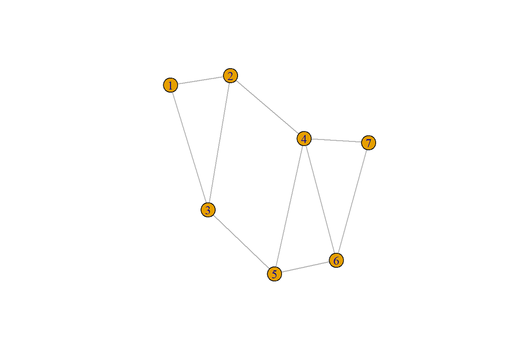

```r
plot(g)
```

La documentación del paquete se encuentra en el siguiente enlace: (https://igraph.org/)

## Red ponderada

Habiendo definido el objeto, puedo manualmente ponderar los enlaces:

```r
# red ponderada no dirigida
wg <- g
E(wg)$weight <- round(runif(n = ecount(wg)), 3) #Lo doy de manera aleatorio

E(wg)$weight
```

```
##  [1] 0.513 0.907 0.502 0.140 0.727 0.267 0.339 0.400 0.766 0.710
```

```r
is_weighted(wg) #Pregunta de si es ponderada
```

```
## [1] TRUE
```

Por supuesto, también podemos graficarla

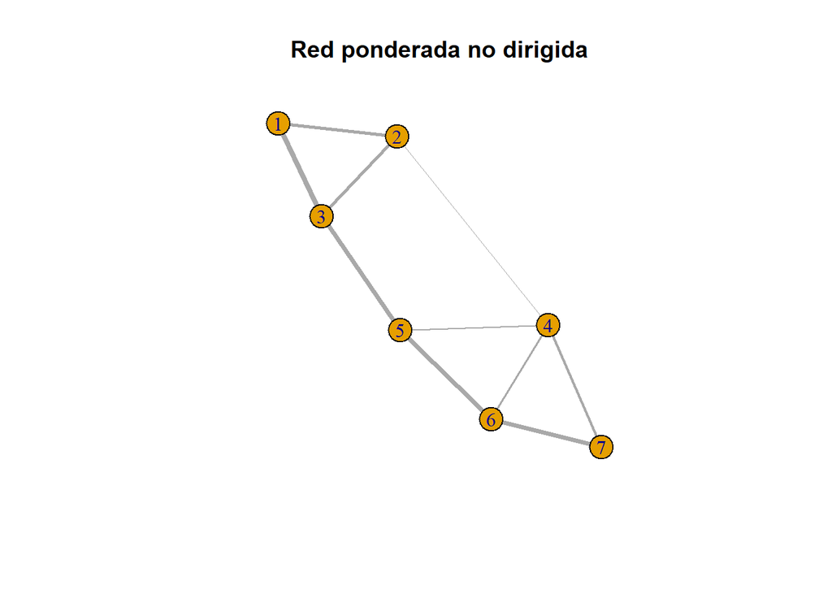

```r
# visualización
set.seed(123)
plot(wg, edge.width = 5*E(wg)$weight, main = "Red ponderada no dirigida")
```

También podemos revisar digrafos o grafos dirigidos

```r
# red binaria dirigida
dg <- graph_from_literal(1-+2, 1-+3, 2++3)

# aristas
E(dg)
```

```
## + 4/4 edges from 03166b1 (vertex names):
## [1] 1->2 1->3 2->3 3->2
```

```r
# etiquetas
V(dg)$name <- c("Juan", "Maria", "Pedro")
# agregar 'sexo' como atributo
V(dg)$sexo <- c("M","F","M")
# aristas
E(dg)
```

```
## + 4/4 edges from 03166b1 (vertex names):
## [1] Juan ->Maria Juan ->Pedro Maria->Pedro Pedro->Maria
```

Veamos la representación gráfica

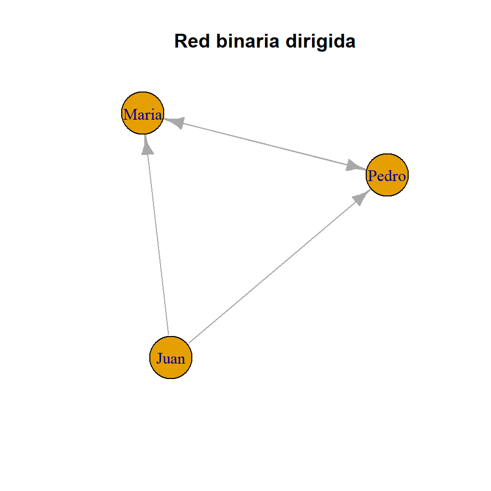

```r
# visualización
set.seed(123)
plot(dg, vertex.size = 35, main = "Red binaria dirigida")
```

Finalmente, podemos graficar multigráfos

```r
# multigrafo
mg <- g + edge(c(1,1), c(1,2), c(1,3))
print_all(mg)
```

```
## IGRAPH 0339cfb UN-- 7 13 --
## + attr: name (v/c)
## + edges (vertex names):
## 1 -- 1, 1, 2, 2, 3, 3
## 2 -- 1, 1, 3, 4
## 3 -- 1, 1, 2, 5
## 4 -- 2, 5, 6, 7
## 5 -- 3, 4, 6
## 6 -- 4, 5, 7
## 7 -- 4, 6
```

```r
# simple?
is_simple(mg)
```

```
## [1] FALSE
```

Veamos los gráficos

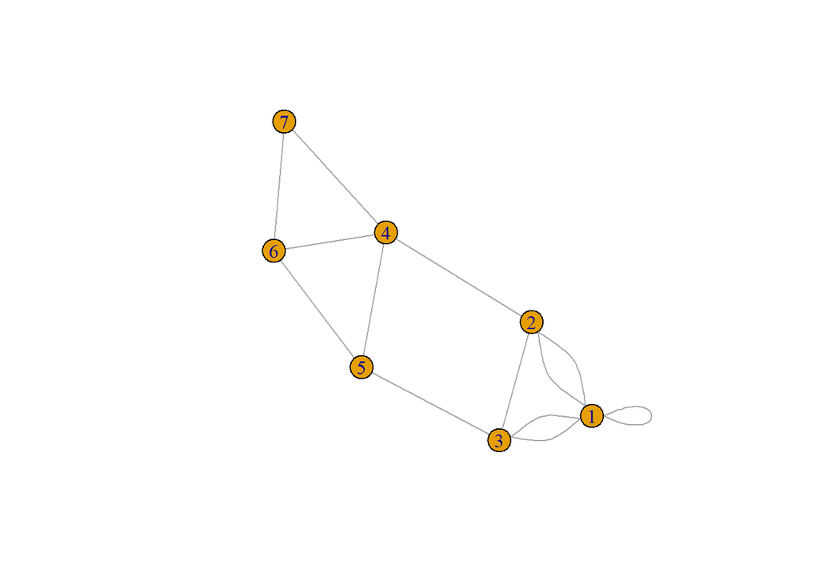

```r
plot(mg)
```

## Estructuras de datos relacionales

Generalmente los grafos no se definen manualmente ya que la mayoría de las redes en la práctica son grandes. Los datos para construir un grafo tipicamente se almacenarán en un **archivo de datos**.